# Subsidies, Sludge, and the Demand for Air Purifiers

A field experiment

Matt Brooks

April 7, 2026

## About me

- 4th-year PhD student in Agricultural and Resource Economics (ARE) at UC Davis
- Originally from a suburb of Boston, MA
- Research interests: environmental economics and development economics
- Behavioral economics is a thread running through both

## Plan for today

1. A bit of theory: positive vs. normative, rational choice model, behavioral economics
2. Walk through one of my studies and how it connects to these ideas
3. Explain the results
4. Lots of time for questions

# Theory

## Positive vs. normative

**Normative:** how people *should* behave according to a model

> “A rational agent facing a lower price should demand more of a good.”

**Positive:** how people *actually* behave in the data

> “When we reduced the price of air purifiers, we observed higher application rates.”

Economics uses both — theory (normative) generates predictions that we test with data (positive).

## The rational choice model

A mathematical model of human behavior based on two core assumptions:

1. **Agents evaluate costs and benefits** of any decision
2. **Agents choose optimally** subject to their constraints

**Implication:** if health benefits exceed cost, a rational agent should adopt an air purifier. Research suggests those benefits far exceed the sticker price — so why do so few people apply?

## iClicker

Given the health benefits exceed the costs, what would the rational choice model predict will happen when we offer people a fully subsidized (i.e., free) air purifier?

1. Nearly everyone accepts the air purifier
2. Almost no one accepts the air purifier
3. Somewhere in between
4. Inconclusive — we need more information

## Behavioral economics

The rational choice model is powerful but relies on strong assumptions. When do they fail?

- **Fail to act** even when benefits clearly outweigh costs (inertia, procrastination)
- **Are deterred by small hassles** more than rational cost-benefit would predict (“sludge”)

**Behavioral economics** studies why these failures occur and what we can do about them.

# The experiment

## Background: air quality and health

- Fine particulate matter (PM2.5) is the **largest environmental risk factor** for health and mortality in the United States (Liang et al., 2021, *PNAS*)
- People spend an estimated **90% of their day indoors**
- Air purifiers can reduce indoor PM2.5 exposure — health benefits likely far exceed their cost; people are leaving health benefits on the table
- **Motivating question:** What is the constraint preventing adoption?

## Research questions

1. **How do subsidies affect application rates?**
   - Does a bigger subsidy lead to more applications, and by how much?
2. **How does “sludge” compare to monetary costs?**
   - Do small non-monetary frictions deter as many applicants as large price increases?
3. **Do these costs change *who* applies?**
   - Does the subsidy level or type of friction shift the income or demographic composition of applicants?
   - Do effects on application rates vary by income and pollution exposure?

## Consistent with rational choice

- Higher subsidies → more applications (downward-sloping demand)

## Inconsistent with rational choice

Health benefits from air purifiers far exceed their cost. Under rational choice, people should apply even at 0% subsidy and tolerate minor paperwork to get a free purifier.

- Yet application rates fall sharply with small price increases and minor administrative requirements
- This scale of deterrence is hard to reconcile with a rational cost-benefit calculation

## Experimental design

~90,000 California households received a mailing, randomly assigned to one of **9 treatment arms:**

| Arm | Label |
| --- | --- |
| T0 | 0% subsidy |
| T1 | 50% subsidy |
| T8 | 75% subsidy |
| T2 | 95% subsidy |
| T3 | 100% subsidy (reference) |
| T4 | 100% subsidy + time cost |
| T5 | 100% subsidy + proof of residence |
| T6 | 100% subsidy + proof of residence + help |
| T7 | 100% subsidy + AQ info |

Stratified randomization by income × household size × PM2.5 quartile.

## Pre-specified hypotheses

All hypotheses pre-registered before data collection. [AEA RCT Registry](https://www.socialscienceregistry.org/trials/17499)

| # | Hypothesis | Arms compared |
| --- | --- | --- |
| H1 | Higher subsidies → more applications | T0, T1, T8, T2 vs. T3 (joint test) |
| H2 | Near-full (95%) subsidy similar to 100%? | T2 vs. T3 |
| H3 | Time cost reduces applications | T4 vs. T3 |
| H4 | Proof of residence requirement reduces applications | T5 vs. T3 |
| H5 | Help with proof of residence makes no difference | T5 vs. T6 |
| H6 | Air quality information changes applications | T7 vs. T3 |

# Results

## iClicker

Which arm do you predict had the **highest** application rate?

1. 0% subsidy
2. 50% subsidy
3. 75% subsidy
4. 95% subsidy
5. 100% subsidy
6. 100% subsidy + time cost
7. 100% subsidy + proof of residence
8. 100% subsidy + proof of residence + help
9. 100% subsidy + AQ info

## Application rates by treatment arm

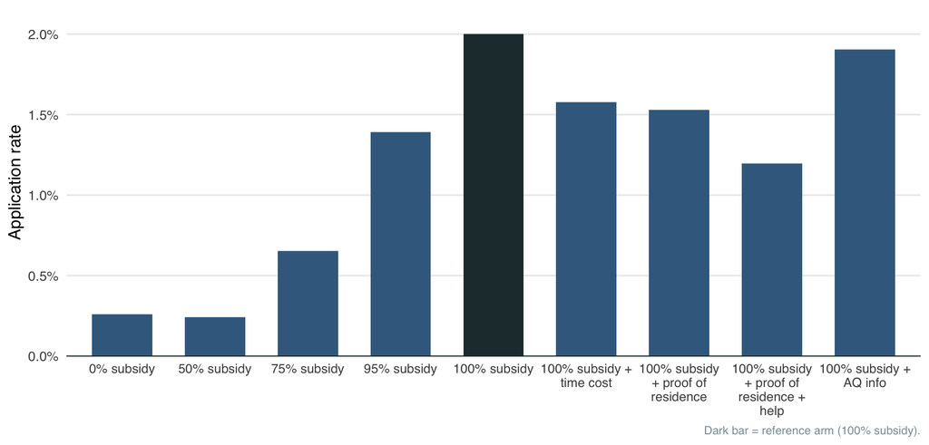

## Demand curve: subsidy arms only

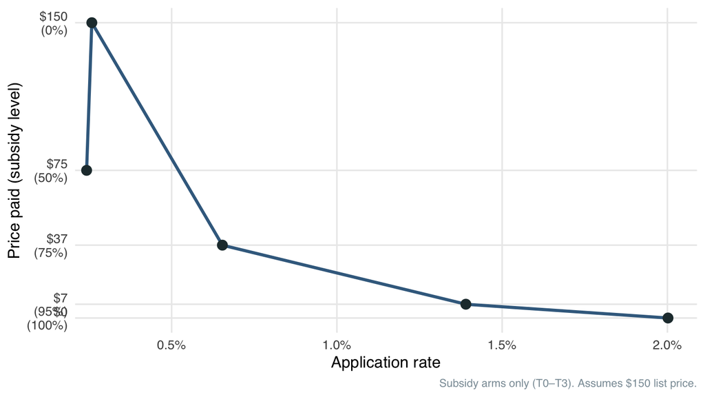

## Application rates: summary table

| Treatment arm | N mailed | Applied | Application rate |
| --- | --- | --- | --- |
| 0% subsidy | 6575 | 17 | 0.26% |
| 50% subsidy | 6590 | 16 | 0.24% |
| 75% subsidy | 6579 | 43 | 0.65% |
| 95% subsidy | 11293 | 157 | 1.39% |
| 100% subsidy | 18483 | 370 | 2.00% |
| 100% subsidy + time cost | 9194 | 145 | 1.58% |
| 100% subsidy + proof of residence | 13067 | 200 | 1.53% |
| 100% subsidy + proof of residence + help | 9203 | 110 | 1.20% |
| 100% subsidy + AQ info | 9195 | 175 | 1.90% |

## ITT regression: application submitted

0% subsidy

−0.017***

(0.001)

50% subsidy

−0.018***

(0.001)

75% subsidy

−0.013***

(0.001)

95% subsidy

−0.006***

(0.002)

100% subsidy + time cost

−0.004**

(0.002)

100% subsidy + proof of residence

−0.005***

(0.001)

100% subsidy + proof of residence + help

−0.008***

(0.002)

100% subsidy + AQ info

−0.001

(0.002)

Num.Obs.

90179

R2

0.006

* p < 0.1, ** p < 0.05, *** p < 0.01

Reference arm: 100% subsidy (T3). HC1 robust SEs. Strata FEs.

## Sludge vs. subsidy costs: hypothesis tests

*Does a non-monetary friction deter applicants by as much as a given price increase?*

| Comparison (H0: equal effects) | p-value |
| --- | --- |
| **Time cost (T4) vs. subsidy arms** |  |
| Time cost (T4) vs. 0% subsidy (T0) | 0.0000 |
| Time cost (T4) vs. 50% subsidy (T1) | 0.0000 |
| Time cost (T4) vs. 75% subsidy (T8) | 0.0000 |
| Time cost (T4) vs. 95% subsidy (T2) | 0.2746 |
| **Proof of residence + help (T6) vs. subsidy arms** |  |
| Proof of res. + help (T6) vs. 0% subsidy (T0) | 0.0000 |
| Proof of res. + help (T6) vs. 50% subsidy (T1) | 0.0000 |
| Proof of res. + help (T6) vs. 75% subsidy (T8) | 0.0003 |
| Proof of res. + help (T6) vs. 95% subsidy (T2) | 0.2175 |
| **Time cost vs. proof of residence arms** |  |
| Time cost (T4) vs. proof of res. (T5) | 0.7843 |
| Time cost (T4) vs. proof of res. + help (T6) | 0.0272 |

HC1 robust SEs. Strata FEs. Non-italic rows: cannot reject equal effects (p ≥ 0.10).

## Multiple hypothesis testing

*6 pre-specified hypotheses. Benjamini (2006) sharpened q-values correct for multiple testing within each outcome.*

| Hypothesis | Submitted p | Submitted q | Log income p | Log income q |
| --- | --- | --- | --- | --- |
| H1: subsidy level matters (T0=T1=T8=T2=0) | 0.0000 | 0.0000 | 0.2970 | 0.5939 |
| H2: 95% vs. 100% subsidy (T2=0) | 0.0001 | 0.0002 | 0.2273 | 0.5939 |
| H3: time cost (T4=0) | 0.0105 | 0.0157 | 0.8884 | 0.8884 |
| H4: proof of residence required (T5=0) | 0.0016 | 0.0031 | 0.8746 | 0.8884 |
| H5: help with proof adds nothing (T5=T6) | 0.0320 | 0.0384 | 0.2643 | 0.5939 |
| H6: AQ information (T7=0) | 0.5721 | 0.5721 | 0.8504 | 0.8884 |

## Application funnel: proof of residence arms

*Did informing applicants about the document requirement screen out those who would not complete?*

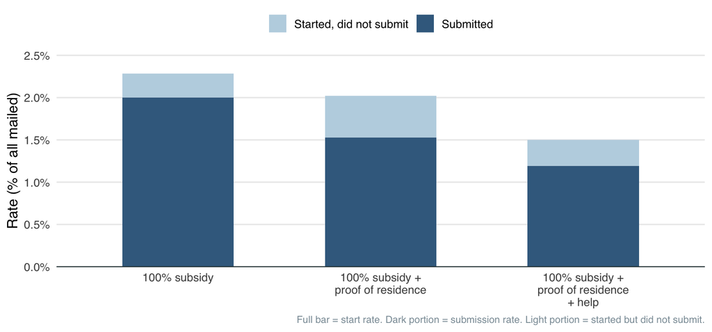

## Application funnel: table

| Treatment | N mailed | Started | Start rate | Submitted | Completion rate* | Submit rate |
| --- | --- | --- | --- | --- | --- | --- |
| 100% subsidy | 18483 | 422 | 2.28% | 370 | 87.7% | 2.00% |
| 100% subsidy + proof of residence | 13067 | 264 | 2.02% | 200 | 75.8% | 1.53% |
| 100% subsidy + proof of residence + help | 9203 | 138 | 1.50% | 110 | 79.7% | 1.20% |

* Completion rate = submitted / started

## iClicker

Do you think treatment arms with higher subsidies resulted in more applicants with lower income?

1. Yes
2. No
3. Inconclusive

## Who applies? Demographics of applicants

|  | Low income (mailer) | White non-Hispanic | English at home |
| --- | --- | --- | --- |
| 0% subsidy | 0.000 | −0.053 | −0.062 |
|  |  | (0.131) | (0.100) |
| 50% subsidy | 0.000 | −0.078 | 0.062 |
|  |  | (0.150) | (0.081) |
| 75% subsidy | 0.000 | 0.069 | 0.013 |
|  |  | (0.089) | (0.079) |
| 95% subsidy | 0.000 | 0.025 | 0.008 |
|  |  | (0.052) | (0.042) |
| 100% subsidy + time cost | 0.000 | 0.043 | 0.051 |
|  |  | (0.056) | (0.041) |
| 100% subsidy + proof of residence | 0.000 | −0.073 | −0.009 |
|  |  | (0.048) | (0.039) |
| 100% subsidy + proof of residence + help | 0.000 | −0.070 | −0.025 |
|  |  | (0.059) | (0.049) |
| 100% subsidy + AQ info | 0.000 | −0.029 | −0.028 |
|  |  | (0.050) | (0.039) |
| Num.Obs. | 1233 | 1233 | 1233 |
| R2 | 1.000 | 0.242 | 0.341 |

* p < 0.1, ** p < 0.05, *** p < 0.01  
Sample: submitted == 1. HC1 robust SEs. Strata FEs. Reference arm: 100% subsidy (T3).

## Who applies? Income distribution (KS tests)

| Arm vs. 100% reference | KS statistic | p-value |
| --- | --- | --- |
| 0% subsidy | 0.2820 | 0.2022 |
| 50% subsidy | 0.1461 | 0.8741 |
| 75% subsidy | 0.0902 | 0.9459 |
| 95% subsidy | 0.1429 | 0.0460 |
| 100% subsidy + time cost | 0.0638 | 0.8537 |
| 100% subsidy + proof of residence | 0.1128 | 0.1155 |
| 100% subsidy + proof of residence + help | 0.0918 | 0.5575 |
| 100% subsidy + AQ info | 0.0817 | 0.5113 |

Pairwise KS tests vs. 100% subsidy reference (T3). Log income among applicants.

## HTE: by income group — specification

Does the *effect* of each treatment arm differ for high-income vs. low-income households?

$$y_i = \alpha + \sum_{j \neq 3} \beta_j
T_{ij} + \delta \cdot \text{HiInc}_i + \sum_{j \neq 3} \gamma_j (T_{ij}
\times \text{HiInc}_i) + \mu_s + \varepsilon_i$$

- $T_{ij}$ = 1 if arm $j$ (ref: T3); $\text{HiInc}_i$ = 1 if mailer income > $75k; $\mu_s$ = strata FE
- **Table shows $\hat{\gamma}_j$** (interaction terms only)

## HTE: by income group

0% × high income

−0.003

(0.003)

50% × high income

−0.003

(0.003)

75% × high income

0.000

(0.003)

95% × high income

0.002

(0.003)

100%+TC × high income

−0.002

(0.004)

100%+POR × high income

0.000

(0.003)

100%+POR+help × high income

−0.001

(0.003)

100%+AQ × high income

0.004

(0.004)

Num.Obs.

90179

R2

0.006

* p < 0.1, ** p < 0.05, *** p < 0.01

## HTE: by PM2.5 exposure — specification

Does the *effect* of each treatment arm differ for households with high vs. low pollution exposure?

$$y_i = \alpha + \sum_{j \neq 3} \beta_j
T_{ij} + \delta \cdot \text{HiPM}_{i} + \sum_{j \neq 3} \gamma_j (T_{ij}
\times \text{HiPM}_{i}) + \mu_s + \varepsilon_i$$

- $T_{ij}$ = 1 if arm $j$ (ref: T3); $\text{HiPM}_i$ = above-median PM2.5 (Census tract, CES 5.0); $\mu_s$ = strata FE
- **Table shows $\hat{\gamma}_j$** (interaction terms only)

## HTE: by PM2.5 exposure

0% × high PM2.5

−0.002

(0.002)

50% × high PM2.5

0.000

(0.002)

75% × high PM2.5

−0.002

(0.003)

95% × high PM2.5

−0.001

(0.003)

100%+TC × high PM2.5

−0.002

(0.003)

100%+POR × high PM2.5

−0.006**

(0.003)

100%+POR+help × high PM2.5

−0.003

(0.003)

100%+AQ × high PM2.5

−0.007**

(0.004)

Num.Obs.

90179

R2

0.006

* p < 0.1, ** p < 0.05, *** p < 0.01

# Taking stock

## What fits the rational choice model

- **Higher subsidies → more applications** (H1 confirmed): demand slopes downward
  - 0% subsidy arm has dramatically lower take-up than 100% arm

The core prediction — monetary price matters — holds up.

## What is harder to explain (1/2)

**Non-monetary frictions are surprisingly large** relative to monetary costs

## What is harder to explain (2/2)

**Did informing applicants about the document requirement screen out those who wouldn’t complete it?**

- T5 (informed of requirement) and T6 (informed + helped) both affect the *composition* of who starts and who completes
- If start rates fall but completion rates rise, people may be rationally self-selecting in response to the information
- See the funnel slide for the data

## Questions?

**Thank you!**

Matt Brooks | msbrooks@ucdavis.edu | mspitzerbrooks.github.io

**Feedback:** tinyurl.com/133matt

[figure not shown]